# IE Project

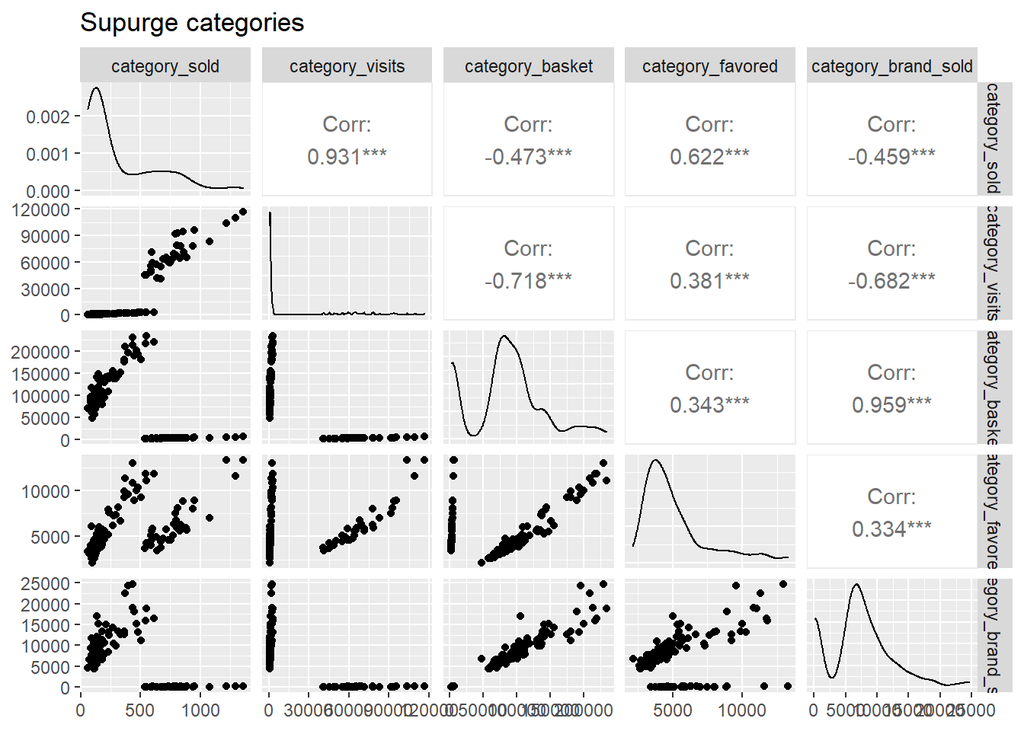

```r
ggpairs(supurge, columns = c(8,9,10,11,12),title ="Supurge categories")
```

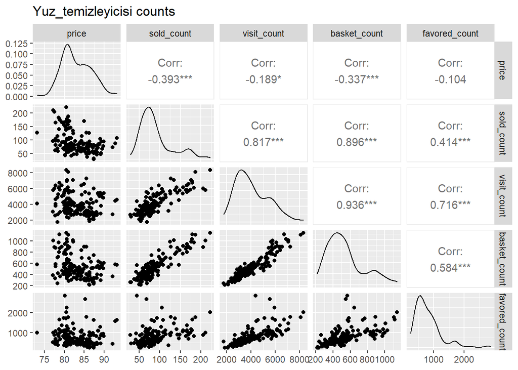

```r
ggpairs(yuz_temizleyicisi, columns = c(3,4,5,6,7),title = "Yuz_temizleyicisi counts")
```

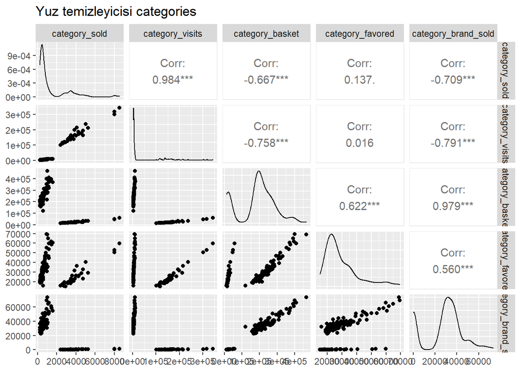

```r
ggpairs(yuz_temizleyicisi, columns = c(8,9,10,11,12),title ="Yuz temizleyicisi categories")
```

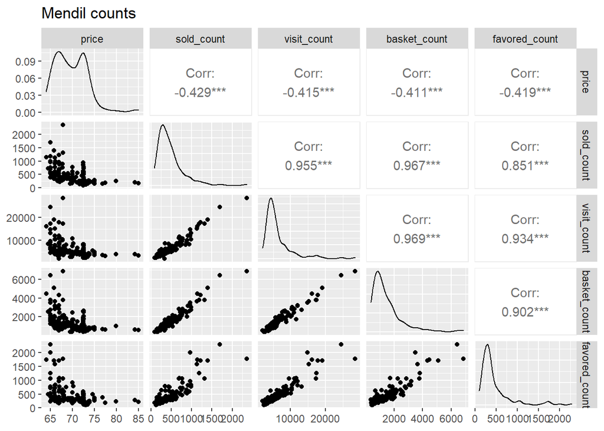

```r
ggpairs(mendil, columns = c(3,4,5,6,7),title = "Mendil counts")
```

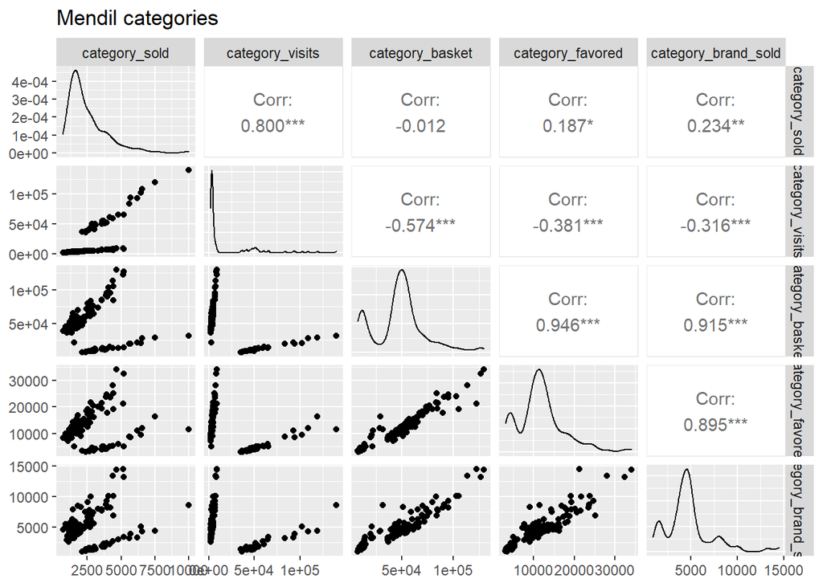

```r
ggpairs(mendil, columns = c(8,9,10,11,12),title ="Mendil categories")
```

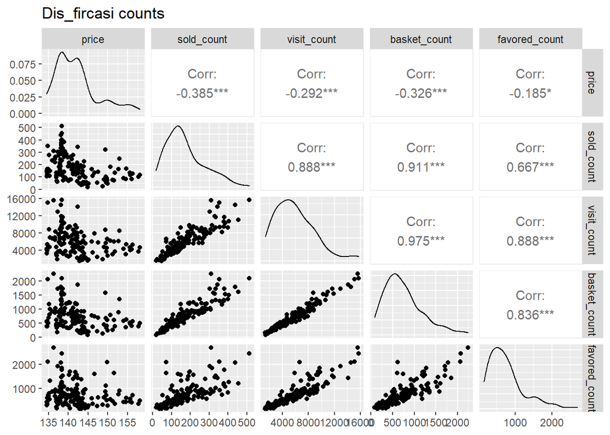

```r
ggpairs(dis_fircasi, columns = c(3,4,5,6,7),title = "Dis_fircasi counts")
```

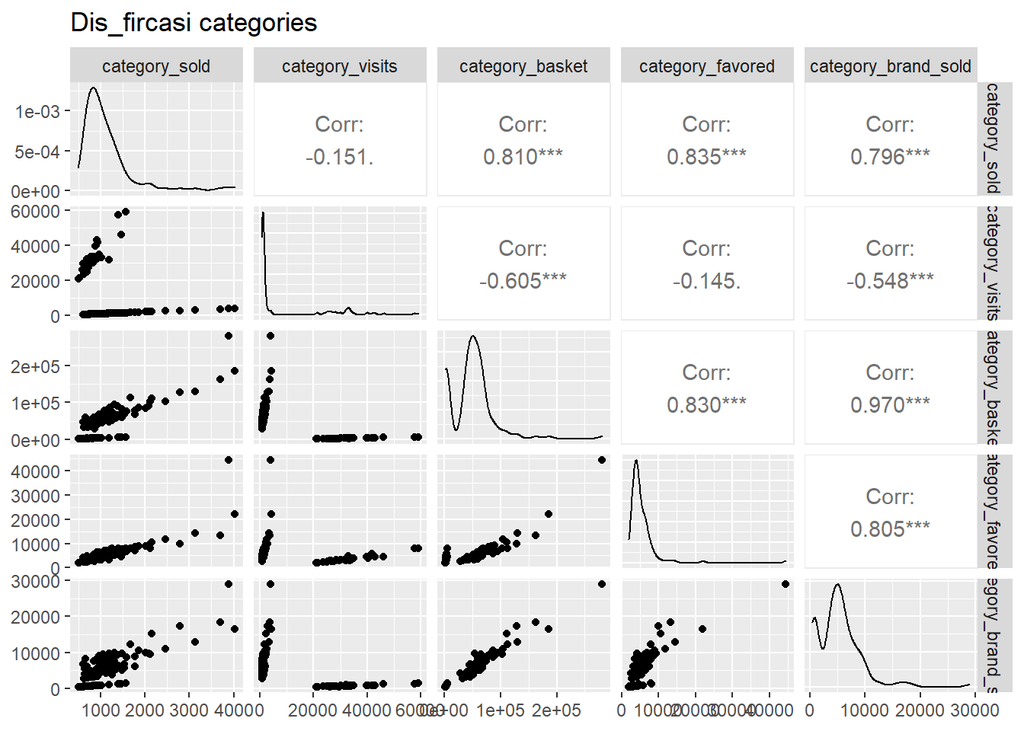

```r
ggpairs(dis_fircasi, columns = c(8,9,10,11,12),title ="Dis_fircasi categories")
```

We see that price has a dominant negative correlation with sold_count in general and basket_count and visit_count regressors are most dominant positive correlated ones.

# Related Literature

The linear model and arima model are the ones we used to predict next day’s sales quantity but other approaches could be used. The main sources of our approach comes from IE_360 lectures and lecture videos in moodle system. No other external source method is used. One may also could use GAM method which is generialized additive models. Rather modelling linearly and discretely , we can model and fit the data by introducing contuinity in the data. SARIMAX or ARIMAX models would also perform efficiently. Our ARIMA model does not contain regressor or seasonality but we add these parts in the linear model so that arima deals only with the residuals. Our method is not the perfect one but when we search what is to be the best method , we encountered with the long short-term memory method.Long short-term memory (LSTM) is an artificial recurrent neural network (RNN) architecture used in the field of deep learning. Unlike standard feedforward neural networks, LSTM has feedback connections. It can not only process single data points (such as images), but also entire sequences of data (such as speech or video). Here is the wikipedia explanation and since it includes stuff that we have not learned in the class , we did not use this method. Xgboost usage seemed us to be a quick tricky way to extract the necessary features , hence we continued with our common sense and we discussed and found new regressors as we will see.

# Approach

Our model we used in the API competition consists of 2 fundamental parts: Linear Model and ARIMA on residuals. We used the pipeline approach to code efficiently and to analyse easily. Our pipeline consists of 4 main functions : preperation, point forecast, performance and estimate. We will open up each of them as we move on.

## Model Preperation Function

Here we introduce our preperation function which handles data row reversing, trend component addition ,traffic regressor addition and difference regressor addition. The function takes non-processed data and outputs the processed version of it.

```r
preperation <- function(X){
  input_data = X
  len = length(input_data$price)
  input_data <- input_data %>% map_df(rev)
  trend = seq(1:len)
  input_data<-cbind(input_data,trend)
  input_data <- input_data %>% mutate(traffic =
                                        case_when(ty_visits >= mean(quantile(input_data$ty_visits)[3],quantile(input_data$ty_visits)[4]) ~ 1,
                                                  ty_visits < mean(quantile(input_data$ty_visits)[3],quantile(input_data$ty_visits)[4]) ~ 0,
                                        )
  )

  difference <-diff(input_data$sold_count)
  difference[len]=0
  input_data<-cbind(input_data,difference)

  z<-input_data
  return (z)

}
```

Here there is a wider explanatory definitions :

data-row-reversing : before entering preperation function data rows are ordered by decreasing event date but we wanted to have latest data to be at the bottom.It is just a practice choice.

trend-component-addition : Since we saw that some of the products’sales quantity contains a trend in their acf graph, we decided to add a numeric trend colum.

## Point Forecast Function

Since we will predict next day’s sales quantity , we need to handle next day’s regressors’ values :

```r
point_forecast <- function(X) {

  input_data = X
  len = length(input_data$price)

  new_price = forecast(input_data$price,1)$mean[1]
  new_visit_count = round(forecast(input_data$visit_count,1)$mean[1])
  new_basket_count = round(forecast(input_data$basket_count,1)$mean[1])
  new_favored_count = round(forecast(input_data$favored_count,1)$mean[1])
  new_cat_sold = round(forecast(input_data$category_sold,1)$mean[1])
  new_cat_visits = round(forecast(input_data$category_visits,1)$mean[1])
  new_cat_basket = round(forecast(input_data$category_basket,1)$mean[1])
  new_cat_favored = round(forecast(input_data$category_favored,1)$mean[1])
  new_cat_brand = round(forecast(input_data$category_brand_sold,1)$mean[1])
  new_ty = round(forecast(input_data$ty_visits,1)$mean[1])
  new_soldout = round(forecast(input_data$soldout,1)$mean[1])
  new_lagg = round(forecast(input_data$lagg,1)$mean[1])
  new_traffic = round(forecast(input_data$traffic,1)$mean[1])

  newdate = input_data$event_date[len]+1
  newwday = weekdays(newdate)
  newmon = months(newdate)

  newrow <- data.frame(event_date=newdate,stringsAsFactors=F)
  input_data <- rbind.fill(input_data,newrow)



  input_data$product_content_id[len+1] <-  input_data$product_content_id[2]
  input_data$wday[len+1] <- newwday
  input_data$mon[len+1] <- newmon
  input_data$price[len+1] <- new_price
  input_data$visit_count[len+1] <- new_visit_count
  input_data$basket_count[len+1] <- new_basket_count
  input_data$favored_count[len+1] <- new_favored_count
  input_data$category_sold[len+1] <- new_cat_sold
  input_data$category_visits[len+1] <- new_cat_visits
  input_data$category_favored[len+1] <- new_cat_favored
  input_data$category_basket[len+1] <- new_cat_basket
  input_data$category_brand_sold[len+1] <- new_cat_brand
  input_data$ty_visits[len+1] <- new_ty
  input_data$soldout[len+1] <- new_soldout
  input_data$lagg[len+1] <- new_lagg
  input_data$trend[len+1] <- len+1
  input_data$traffic[len+1] <- new_traffic


  z <- input_data
  return (input_data)
}
```

We used this function but it was essentially necessarily not so useful , since the point forecasting of regressors were adding up the error and error accumulation was inevitable.

## Model Performance Function

This function is the core of the all processes. Here we apply linear model and after extracting the residuals from LM we use them in the ARIMA model.

```r
performance <- function(X
){
  input_data =X

  if(deparse(substitute(X))=="mont"){
    fit <- lm(sold_count ~ price   +soldout+(sold_count/visit_count) , data = input_data)

  }
  else{

    if (sum(input_data$soldout)==0) {
      fit <- lm(sold_count ~ price   +input_data$difference+ lagg +(visit_count/category_visits)+wday+mon  + trend  + (basket_count/category_basket) + (favored_count/category_favored)  +(sold_count/(category_sold))+ as.factor(traffic)  , data = input_data)
    } else {
      fit <- lm(sold_count ~ price   +input_data$difference+soldout+ lagg +(visit_count/category_visits)+wday+mon  + trend  + (basket_count/category_basket) + (favored_count/category_favored)  +(sold_count/(category_sold))+ as.factor(traffic)  , data = input_data)
    }
  }



  summary(fit)
  checkresiduals(fit)

  model=auto.arima(residuals(fit),seasonal=F,
                   trace=T,stepwise=F,approximation=F)

  model_fitted = residuals(fit) - residuals(model)
  predicted=floor(predict(fit) + model_fitted)



  error=input_data$sold_count-predicted

  mean=mean(input_data$sold_count)
  MAD=sum(abs(error))/length(input_data$sold_count)
  WMAPE=MAD/mean
  my_list <- list("data" = input_data, "lm" = fit, "arima" = model,"wmape"=WMAPE)
  return(my_list)

}
```

### Linear Model Part

#### Product Categories from our perspective

We shall explain this function step by step since its most important one.We divided products into 3 categories : one being the mont itself, one being having no soldouts,i.e. the product is always sold given the time interval , one being having at least some soldouts hence the long zero sale-days happening. This was obtained from general investigation of the graphs above sections. Mont is treated as a special product since it only responded price,soldout and (sold_count/visit_count) regressors during testing.

#### New regressor detected ! : conversion Rate (Sold_count/visit_count)

Sold_count/visit_count is also newly introduced regressor which represents the “conversion rate” as in the Key Performance Indicators(KPI) jargon.

#### New regressors detected ! : category_visit_conversion_rate , category_basket_conversion_rate , category_sold_conversion_rate ,category_favored_conversion_rate

Here 4 similar regressors added to the linear model as well. We decided to represent the conversion rates of visits,baskets, sold_counts and favoring the item scaling them to their respective categories . By doing that , we were able to compare the given product to other items in the same category in terms of visits,basket numbers, favoring numbers and sold-counts.

Abbreviations :

category_visit_conversion_rate : (visit_count/category_visits), category_basket_conversion_rate : (basket_count/category_basket), category_sold_conversion_rate : (sold_count/(category_sold), category_favored_conversion_rate : (favored_count/category_favored)

All in all , the regressors being used are in general : price , lag(1),difference,traffic, wday(weekday),mon(month), trend, soldout, conversion_rate, category_visit_conversion_rate , category_basket_conversion_rate , category_sold_conversion_rate ,category_favored_conversion_rate

### Evaluation / WMAPE

The model evaluation metric is chosen to be WMAPE(wieghted mean average percentage error). It is basically calculated as follows : we substract the actual value from predicted on to get the error. MAD(mean absolute deviation) is also calculated by taking mean of all daily error summation.At the end ,WMAPE equals to MAD divided by the mean of actual values.

The function takes each product as an input and gives a list of outputs.The list returns as an output containg : processed input , linear model itself, arima model itself and WMAPE result.

## Estimate Function

Now its time to predict the next day’s sales quantity.

```r
estimate <- function(Y,linear,ariba
){
  input_data=Y
  len=length(input_data$price)
  fit = linear
  model = ariba
  model_fitted = residuals(fit) - residuals(model)
  future = predict(model, n.ahead =1)$pred
  res = mean(tail(residuals(fit),3))
  res = rep(res,1)
  future_fitted = res - future
  last_day=mean(predict(fit)[(length(input_data$sold_count)-1):(length(input_data$sold_count)-3)])
  estimated=abs(round(last_day +future_fitted))
  return (estimated)
}
```

The estimation is done as follows : we predict arima residual for 1 period of time and take the mean of last 3 days’ residuals of linear model and substract them, so we obtain the predicted residuals. We also take the mean of last 3 days’ predictions and add it to the predicted residuals. Here we see that we dont actually use point forecasting of regressors since the error accumulation was a big issue, here we use the last 3 predicted values from linear model and this will give us better results.

## Overall Pipeline

Overall pipeline consists of all 4 functions and it also prints WMAPE and the predicted value for the next day’s sales quantity.

```r
pipeout <-function(X){
  X_prep=preperation(X)
  X_perf=performance(X_prep)
  error = X_perf$wmape
  print(error)

  X_new<-point_forecast(X_prep)
  B=estimate(X_new,X_perf$lm,X_perf$arima)
  print(B[1])
}
```

# Results

Here we will demonstrate 1 example pipeout for each 3 categories(mont,no soldouts,yes soldouts) that we mentioned.

## Category 1 : Mont

```r
mont <- preperation(mont)
A=performance(mont)
```

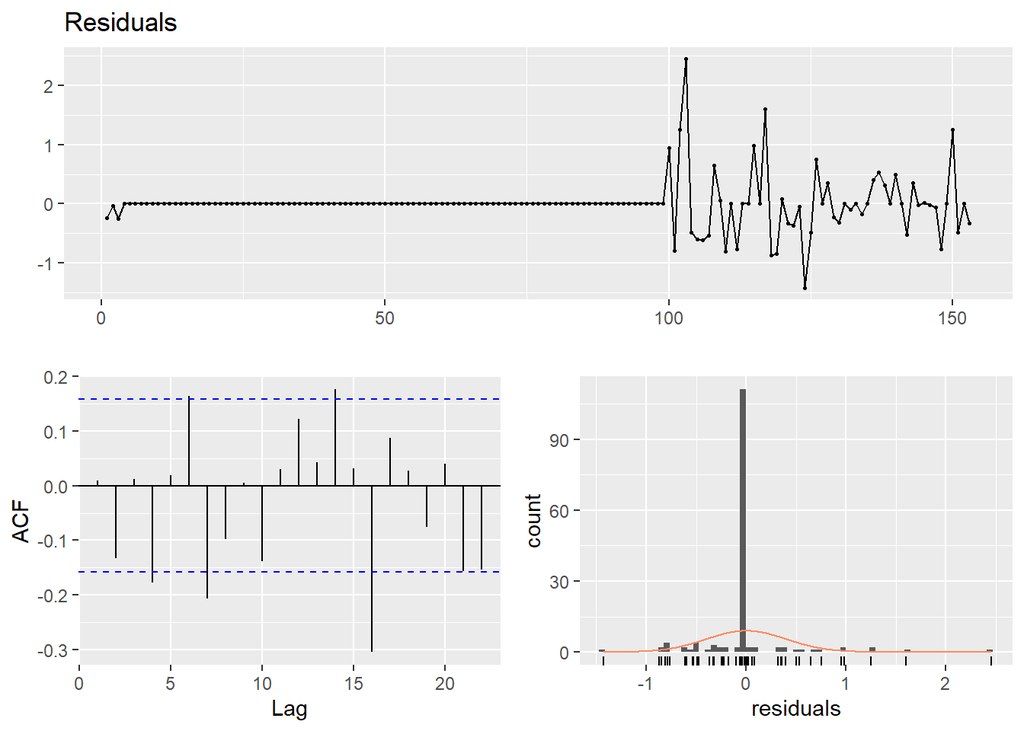

```
##
##  ARIMA(0,0,0) with zero mean     : 154.259
##  ARIMA(0,0,0) with non-zero mean : 156.3126
##  ARIMA(0,0,1) with zero mean     : 156.2969
##  ARIMA(0,0,1) with non-zero mean : 158.378
##  ARIMA(0,0,2) with zero mean     : 154.2706
##  ARIMA(0,0,2) with non-zero mean : 156.3792
##  ARIMA(0,0,3) with zero mean     : 156.3791
##  ARIMA(0,0,3) with non-zero mean : 158.5165
##  ARIMA(0,0,4) with zero mean     : 153.1455
##  ARIMA(0,0,4) with non-zero mean : 155.3047
##  ARIMA(0,0,5) with zero mean     : 155.245
##  ARIMA(0,0,5) with non-zero mean : 157.4326
##  ARIMA(1,0,0) with zero mean     : 156.3011
##  ARIMA(1,0,0) with non-zero mean : 158.3822
##  ARIMA(1,0,1) with zero mean     : 156.5724
##  ARIMA(1,0,1) with non-zero mean : 158.6814
##  ARIMA(1,0,2) with zero mean     : 151.5028
##  ARIMA(1,0,2) with non-zero mean : Inf
##  ARIMA(1,0,3) with zero mean     : Inf
##  ARIMA(1,0,3) with non-zero mean : Inf
##  ARIMA(1,0,4) with zero mean     : 155.2868
##  ARIMA(1,0,4) with non-zero mean : 157.4753
##  ARIMA(2,0,0) with zero mean     : 155.6576
##  ARIMA(2,0,0) with non-zero mean : 157.7666
##  ARIMA(2,0,1) with zero mean     : 156.5804
##  ARIMA(2,0,1) with non-zero mean : 158.7182
##  ARIMA(2,0,2) with zero mean     : 151.8068
##  ARIMA(2,0,2) with non-zero mean : Inf
##  ARIMA(2,0,3) with zero mean     : Inf
##  ARIMA(2,0,3) with non-zero mean : Inf
##  ARIMA(3,0,0) with zero mean     : 157.7344
##  ARIMA(3,0,0) with non-zero mean : 159.8721
##  ARIMA(3,0,1) with zero mean     : 158.7088
##  ARIMA(3,0,1) with non-zero mean : 160.876
##  ARIMA(3,0,2) with zero mean     : Inf
##  ARIMA(3,0,2) with non-zero mean : Inf
##  ARIMA(4,0,0) with zero mean     : 153.0572
##  ARIMA(4,0,0) with non-zero mean : 155.2242
##  ARIMA(4,0,1) with zero mean     : 155.1074
##  ARIMA(4,0,1) with non-zero mean : 157.3043
##  ARIMA(5,0,0) with zero mean     : 154.9516
##  ARIMA(5,0,0) with non-zero mean : 157.1485
##
##
##
##  Best model: ARIMA(1,0,2) with zero mean
```

```r
print(summary(A$lm))
```

```
##
## Call:
## lm(formula = sold_count ~ price + soldout + (sold_count/visit_count),
##     data = input_data)
##
## Residuals:
##    Min     1Q Median     3Q    Max
## -1.428  0.000  0.000  0.000  2.453
##
## Coefficients:
##                          Estimate Std. Error t value Pr(>|t|)
## (Intercept)             2.0048345  0.1907470  10.510  < 2e-16 ***
## price                  -0.0011330  0.0004145  -2.733  0.00703 **
## soldout                -2.0048345  0.1946898 -10.298  < 2e-16 ***
## sold_count:visit_count  0.0019713  0.0001048  18.807  < 2e-16 ***
## ---
## Signif. codes:  0 '***' 0.001 '**' 0.01 '*' 0.05 '.' 0.1 ' ' 1
##
## Residual standard error: 0.4032 on 149 degrees of freedom
## Multiple R-squared:  0.9138, Adjusted R-squared:  0.9121
## F-statistic: 526.5 on 3 and 149 DF,  p-value: < 2.2e-16
```

```r
error = A$wmape
mont<-point_forecast(mont)
B=estimate(mont,A$lm,A$arima)
print(error)
```

```
## [1] 0.3157895
```

```r
print(B[1])
```

```
## [1] 1
```

## Category 2: No Soldout(not including the ‘soldout’ regressor)

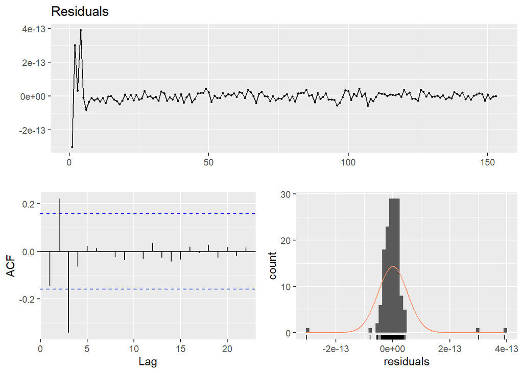

```
## [1] 0.003743902
## [1] 133
```

```r
pipeout(dis_fircasi)
```

## Category 3 : Yes soldout(including the ‘soldout’ regressor)

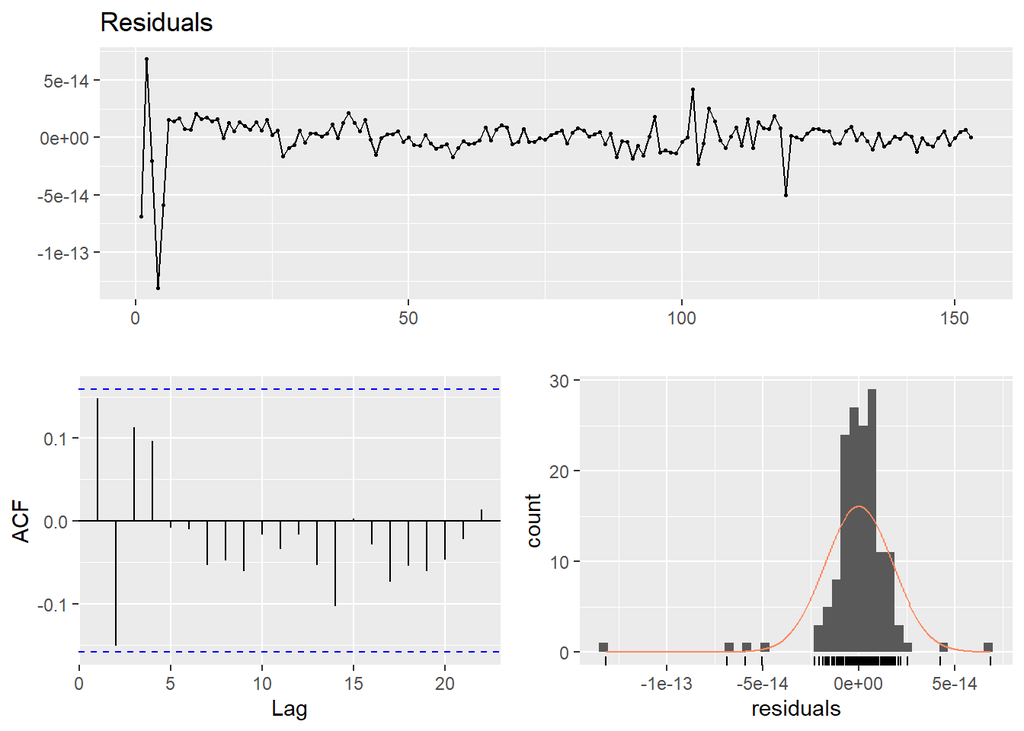

```
## [1] 0.007291385
## [1] 18
```

```r
pipeout(bikini_1)
```

### Overfitting Issues

Here we see that the prediction is 18 for the next day and WMAPE gave us 0.7 percent error meaning that we may ended up overfitting the model. Residuals assumptions are valid and gaussian distribution assumption almost holds , the acf seems to okay in terms of fitting in between dashed confidence interval lines. The overfitting problem comes from having a linear model with R-squared being 1.The reasons getting R-adjusted to be 1 may arises from applying too much regressors or the domination of 1 specific regressor in the model. We see that for the other 8 product the overfitting is a big issue. Overfitting gives us almost perfect models but the prediction becomes unreliable at some points.

# Conclusion and Future Work

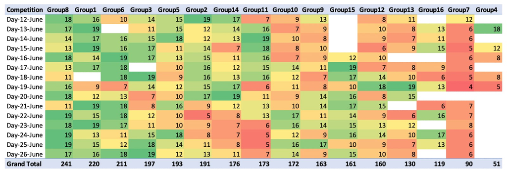

the competition results.As Group2 we ended up in the 6th place

# Code

[Here is the R-script code](https://github.com/BU-IE-360/spring21-YunusEmreErdogan/blob/gh-pages/files/Project/group2_project_report.Rmd)